# Assignment 4

ItsmeHJB

20/10/2021

# Sampling with replacement

## Choose

Choose is done simply using the choose function.

$\binom{n}{k} = \frac{n!}{k!(n-k)!}$

```r
choose(8, 3)
```

```
## [1] 56
```

This is calculating the number of subsets of size 3 from a collection of size 8.

### Example

Prob that z of the 35 balls are red balls

n = 10 balls in the bag r = 3, n-r = 7 k = 35 what is the prob that z of these balls are red omega = {1, …, 10}^35 P(z red balls) = $\binom{35}{z} (\frac{3}{10})^{z} * (1-\frac{3}{10})^{35-z}$

```r
prob_red_spheres <- function(z) {
  val1 <- choose(35, z)
  val2 <- (3/10)**z
  val3 <- (1 - (3/10))**(35-z)

  final <- val1 * val2 * val3
  return(final)
}

prob_red_spheres(20)
```

```
## [1] 0.0005376555
```

Data frame using various values of z

```r
z <- seq(1, 35)
prob <- map_dbl(z, prob_red_spheres)
df_z <- data.frame(z, prob)
prob_by_num_reds <- df_z %>%
  rename(num_reds=z)

prob_by_num_reds%>%head(3)
```

```
##   num_reds         prob
## 1        1 0.0000568228
## 2        2 0.0004139947
## 3        3 0.0019516894
```

Plot these points

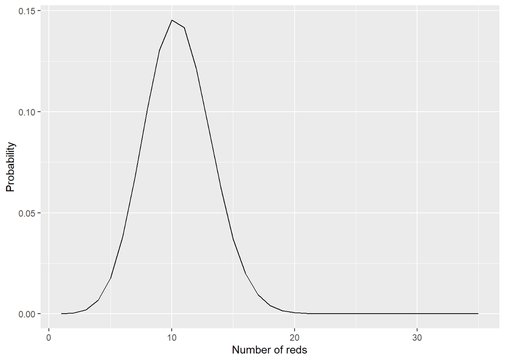

```r
graph <- prob_by_num_reds %>%
  ggplot(aes(x=num_reds, y=prob)) + xlab("Number of reds")
graph + geom_line() + ylab("Probability")
```

## Sample function

In order to replicate this functionality simply, we can use the sample function

```r
sample(10, 35, replace=TRUE)
```

```
##  [1]  3  9  6  3  8  2  5 10  3  8  5  3  5  9 10  4  1  5  9 10  4  4  7  2  9
## [26]  5  4  8  8  6  8  4 10  2  4
```

This is a random experiment with 10 objects, repeated 35 times with replacement

```r
set.seed(0)

for(i in 1:5){
  print(sample(100,5,replace=FALSE))
  # The result may well differ every time
}
```

```
## [1] 14 68 39  1 34
## [1] 87 43 14 82 59
## [1] 51 97 85 21 54
## [1] 74  7 73 79 85
## [1]  37  89 100  34  99
```

```r
## Resetting the random seed every time
for(i in 1:5){
  set.seed(1)
  print(sample(100,5,replace=FALSE))
  # The result should not change
}
```

```
## [1] 68 39  1 34 87
## [1] 68 39  1 34 87
## [1] 68 39  1 34 87
## [1] 68 39  1 34 87
## [1] 68 39  1 34 87
```

We can replicate the example above using sample this time

```r
num_trials<-1000 # set the number of trials
set.seed(0) # set the random seed

sampling_with_replacement_simulation<-data.frame(trial=1:num_trials)%>%
  mutate(sample_balls=map(.x=trial,~sample(10,35,replace = TRUE)))
  # generate collection of num_trials simulations
```

This a data frame containing a number from 1 to 1000 in the first column. The second contains a random sample of 35 numbers from 1 to 10.

To calculate the number of reds in the trial, we need a function which can then be mapped onto the data frame

```r
calc_num_reds <- function(experiment) {
  experiment
}
```